# InformeProyecto1

Marco Ramirez 19588, Alfredo Quezada 191002, Estuardo Hernandez 19202, Eduardo Ramírez 19946

20/3/2022

## Situación Problemática: Situación de los matrimonios en la última década en Guatemala.

## Problema científico:

• Cantidad de menores unidos por el matrimonio a pesar de que existen leyes en Guatemala que prohíben esto.

• Estándares de los matrimonios en Guatemala.

## Objetivos:

Específicos:

1. Determinar la cantidad de menores casados y su respectiva información.
2. Determinar la tendencia de los matrimonios en Guatemala.

General:

1. Determinar el cumplimiento de las leyes matrimoniales en Guatemala

La base de datos que utilizamos fue la de matrimonios, proporcionado por el instituto nacional de estadistica (INE). Esta cuenta con las siguientes variables. **Departamento de registro, Municipio de registro, Mes de registro, Año de registro, Clase de union, Edad del hombre, Edad de la mujer, Grupo etnico del hombre, Grupo etnico de la mujer, Nacionalidad del hombre, Nacionalidad de la mujer, Escolaridad del hombre, Escolaridad de la mujer, Ocupacion del hombre, Ocupacion de la mujer, Departamento de ocurrencia, Municipio de ocurrencia, Dia de ocurrencia, Mes de ocurrencia, Año de ocurrencia**. Las cuales se poseen las siguientes variables numericas y categoricas. Donde las unicas numericas que presentamos son las edades de los individuos.

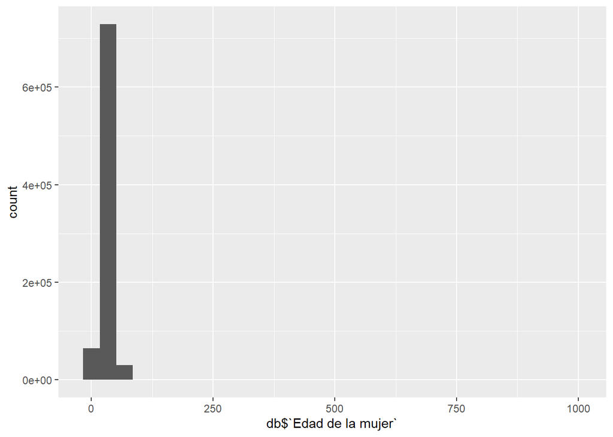

```r
#variables numericas
ggplot(data = db,aes(db$`Edad de la mujer`))+geom_histogram(bins=30)
```

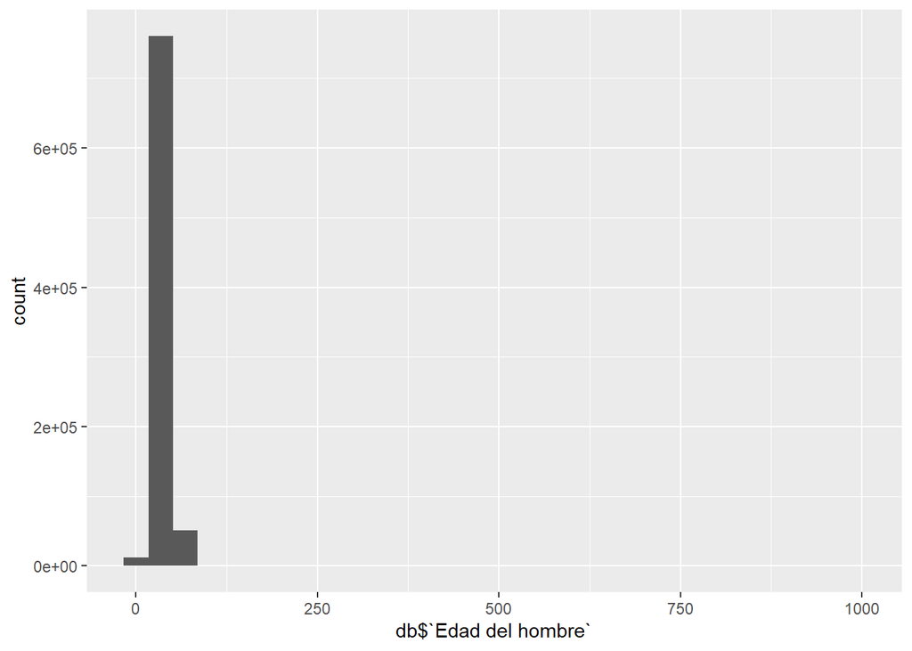

```r
ggplot(data = db,aes(db$`Edad del hombre`))+geom_histogram(bins=30)
```

Tablas de frecuencia

```r
#Variables categoricas

table(db$`Departamento de registro`)
```

```
##
##      1      2      3      4      5      6      7      8      9     10     11
## 171119   9248  21434  41546  39887  19767  22012  28859  51010  37336  20843
##     12     13     14     15     16     17     18     19     20     21     22
##  54955  61836  53313  15417  58446  25415  18747  13193  18137  16087  26781
```

```r
table(db$`Municipio de registro`)
```

```
##
##  0101  0102  0103  0104  0105  0106  0107  0108  0109  0110  0111  0112  0113
## 87451  3075  4239  1240  3093  5617  2364 10785  3493  9898  3697   986  1963
##  0114  0115  0116  0117  0201  0202  0203  0204  0205  0206  0207  0208  0301
##  7231 14941  6683  4363  2128   622  1822   327   671   673  2211   794  3487
##  0302  0303  0304  0305  0306  0307  0308  0309  0310  0311  0312  0313  0314
##  1010   860  2356   765  2053   486  1781  1181   747  1405  1868   687  1692
##  0315  0316  0401  0402  0403  0404  0405  0406  0407  0408  0409  0410  0411
##   760   296  7757  1806  4483  3228  1513  5517  4390   486  2541   894  1378
##  0412  0413  0414  0415  0416  0501  0502  0503  0504  0505  0506  0507  0508
##  1582  1917  1128  1687  1239  7262  6399  1520  2120  2112  3955  3423   885
##  0509  0510  0511  0512  0513  0514  0601  0602  0603  0604  0605  0606  0607
##  3261   835  3490   889  3607   129  2632  3469   868   898   535  1085   439
##  0608  0609  0610  0611  0612  0613  0614  0701  0702  0703  0704  0705  0706
##  2696  1425   971   991   816  1211  1731  5987   210   162  1479  2916  1692
```

[output cut: 40 more lines]

```r
table(db$`Mes de registro`)
```

```
##
##     1     2     3     4     5     6     7     8     9    10    11    12
## 78971 68847 73126 65193 71093 60330 59872 66256 60041 64793 71484 85382
```

```r
table(db$`Año de registro`)
```

```
##
##  2010  2011  2012  2013  2014  2015  2016  2017  2018  2019  2020  2021
## 61830 81420 80943 82602 79984 81544 70403 70834 74952 76148 57207  7521
```

```r
table(db$`Clase de union`)
```

```
##
##      1      2      3      9
##  46915  16509 725142  36822
```

```r
table(db$`Grupo etnico del hombre`)
```

```
##
##      1      2      3      4      5      9
## 296797 104509    241 328485   9129  86227
```

```r
table(db$`Grupo etnico de la mujer`)
```

```
##
##      1      2      3      4      5      9
## 283633 100810    353 317625  10050 112917
```

```r
table(db$`Grupo etnico del hombre`)
```

```
##
##      1      2      3      4      5      9
## 296797 104509    241 328485   9129  86227
```

```r
table(db$`Nacionalidad del hombre`)
```

```
##
##      8     10     12     24     25     32     36     40     44     50     52
##      3     11      1      1      1     62     18     14      1      1      3
##     56     60     68     76     84    100    124    152    156    170    188
##     15      2     21     35     23      3    122     49     26    179    118
##    191    192    208    210    214    218    222    246    270    275    276
##      4    168      9      1     65     48   1000      1      1      3     95
##    300    316    320    324    332    340    348    352    356    364    368
##      2      2 817986      3      2    354      1      1     11      5      2
##    372    376    380    392    400    404    408    410    414    422    438
##     13     16     59      6     14      1      1     48      3      9      1
##    470    480    484    504    508    554    566    568    578    586    600
##      1      1    665      3      1      2      3     74      8      1      9
##    604    608    616    620    630    642    643    670    688    705    710
##     90      5     11      9     36      6      9      1      1      1      3
##    716    718    720    721    723    724    725    752    756    760    804
##      1     35    492      1    892    196      3     17     21     14      1
##    807    818    826    840    858    862   1020   1021   1026   1029   1034
##      2      8      3   1886     26     45     82     10     33      4     23
##   1043   1045   9999
##      7      1      1
```

```r
table(db$`Escolaridad del hombre`)
```

```
##
##      1      2      3      4      5      6      9
## 124900 274448 132708 206869  30888    212  55363
```

```r
table(db$`Escolaridad de la mujer`)
```

```
##
##      1      2      3      4      5      6      9
## 177332 240756 109070 200756  26490    140  70844
```

```r
table(db$`Departamento de ocurrencia`)
```

```
##
##      1      2      3      4      5      6      7      8      9     10     11
## 168221   9329  23490  41491  40223  19753  22464  29148  50790  37317  21030
##     12     13     14     15     16     17     18     19     20     21     22
##  54741  61839  53231  15409  58489  25465  18814  13200  18246  15987  26711
```

```r
table(db$`Dia de ocurrencia`)
```

```
##
##     1     2     3     4     5     6     7     8     9    10    11    12    13
## 21747 23103 24705 25288 26837 26652 26335 27776 26845 26981 26500 27642 26093
##    14    15    16    17    18    19    20    21    22    23    24    25    26
## 29596 27506 28004 28572 29174 28558 29892 28398 28560 27020 25648 27149 27800
##    27    28    29    30    31
## 28891 29785 25496 25008 13827
```

```r
table(db$`Mes de ocurrencia`)
```

```
##
##     1     2     3     4     5     6     7     8     9    10    11    12
## 64105 71251 74307 66712 62202 56772 63371 66549 55871 69116 84041 91091
```

```r
table(db$`Año de ocurrencia`)
```

```
##
##  2010  2011  2012  2013  2014  2015  2016  2017  2018  2019  2020
## 73124 78286 84253 80750 79496 79177 69613 71597 74777 76928 57387
```

### Analisis Exploratorio, sección menores de edad.

#### Matrimonio entre menores de edad

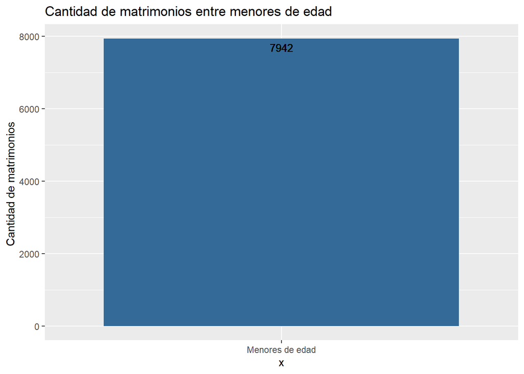

```r
pregunta3
```

Segun el analisis realizado en la base de datos, se encontro que, ha habido una cantidad total de **7942** matrimonios realizados entre dos personas menores de edad durante el año 2010 a 2020. Sin embargo, segun el articulo 84, del codigo civil, expone lo siguiente, *“Artículo 84. Prohibición de contraer matrimonio. No podrán contraer matrimonio ni autorizarse de manera alguna, el matrimonio de menores de dieciséis (16) años de edad.”*

```r
#Resumen de la edad de la mujer
summary(replace(db$`Edad de la mujer`, db$`Edad de la mujer`==999, NA), na.rm = TRUE)
```

```
##    Min. 1st Qu.  Median    Mean 3rd Qu.    Max.    NA's
##   10.00   20.00   23.00   26.32   29.00   99.00     584
```

No obstante, se demostro que existen muchos matrimonios entre menores de edad, e incluso encontrando que la edad minima de las mujeres fue de **10** años.

```r
#Resumen hombre
summary(replace(db$`Edad del hombre`, db$`Edad del hombre`==999, NA), na.rm = TRUE)
```

```
##    Min. 1st Qu.  Median    Mean 3rd Qu.    Max.    NA's
##   12.00   22.00   26.00   29.33   32.00   99.00     576
```

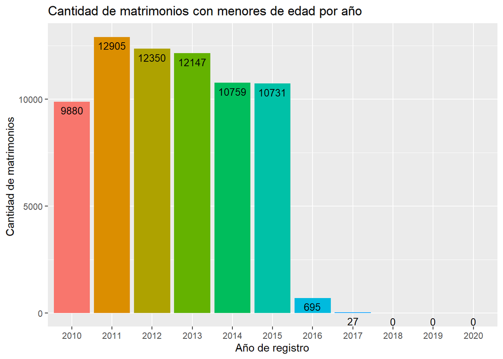

```r
pregunta4
```

#### Matrimonios donde al menos uno es menor de edad

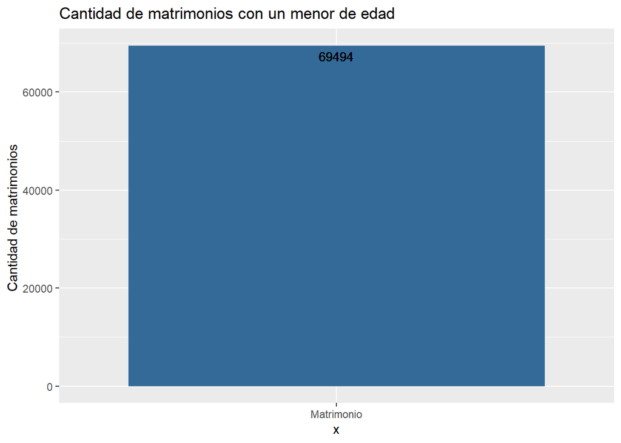

```r
pregunta5
```

La grafica anterior demuestra que ha habido una cantidad de **69494** matrimonios donde al menos uno de la relacion es menor de edad. Nuevamente evidenciando el incumplimiento de la ley, ademas cabe mencionar que una gran parte de este es cuando el Hombre es mayor que la mujer.

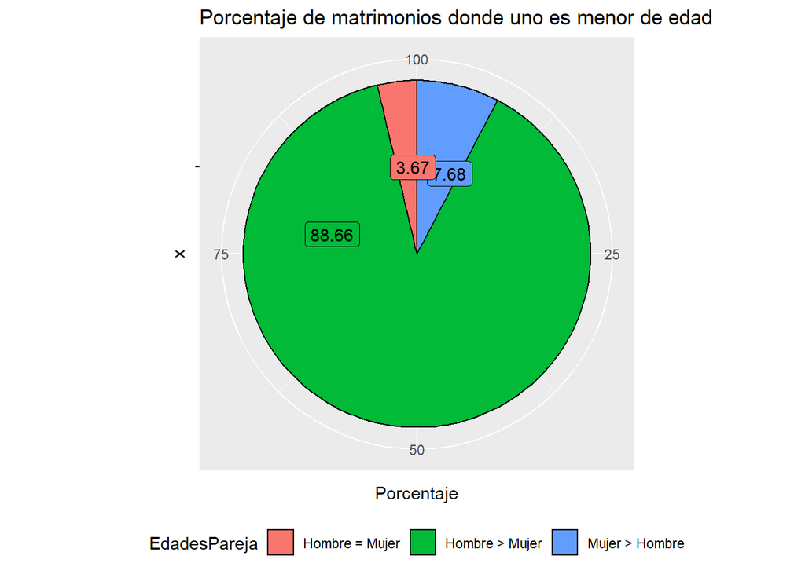

```r
pregunta6
```

Tal como se observa del **100%** de los matrimonios donde exista algun menor el **88.66%** es cuando la mujer es menor de edad y el hombre es mayor que ella, el **7.68%** es cuando el hombre es menor de edad y el **3.67%** cuando ambos individuos comparten la misma edad y tambien son menores de edad. Ahora si nos enfocamos en la diferencia entre las edades se obtiene lo siguiente

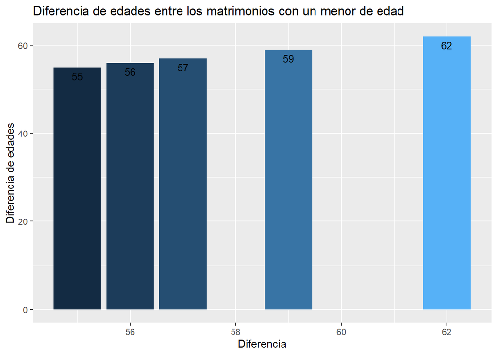

```r
diffEdades
```

Como se observa la mayor diferencia entre un menor de edad y su pareja es de 62 años y siguiendole la edad de 59 años. Ahora si vemos las edades agrupadas obtenemos lo siguiente.

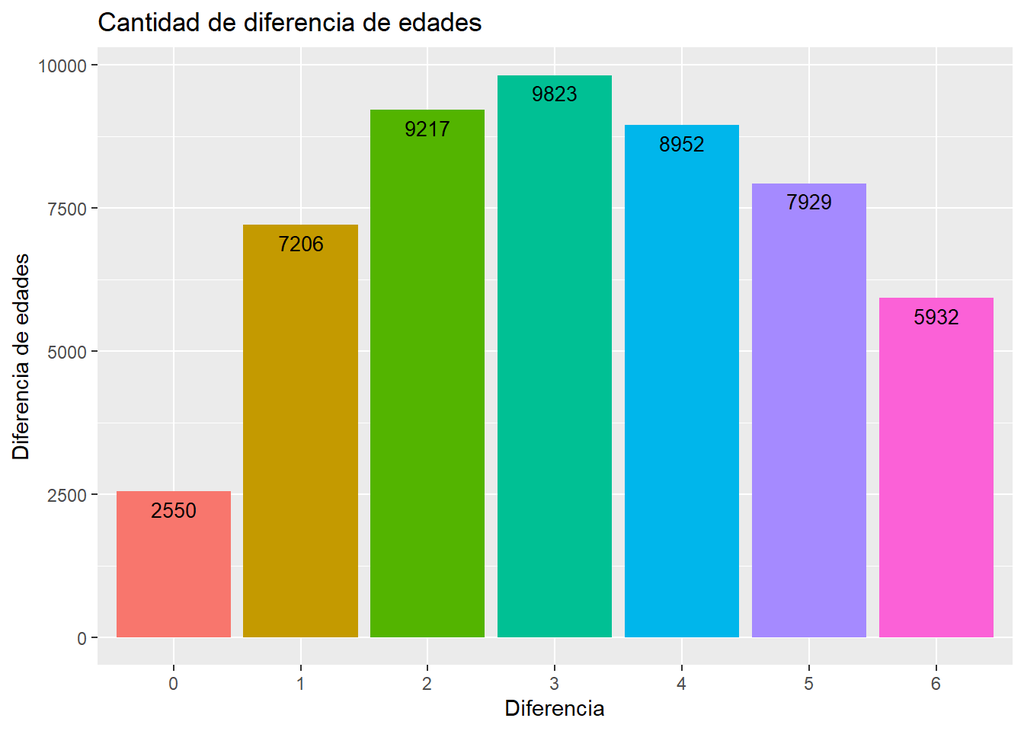

```r
diffEdadesG
```

Tal como se ve en la grafica la mayor diferencia de edades entre un menor de edad y su pareja es de 3 años, y en segundo lugar es de 2 años.

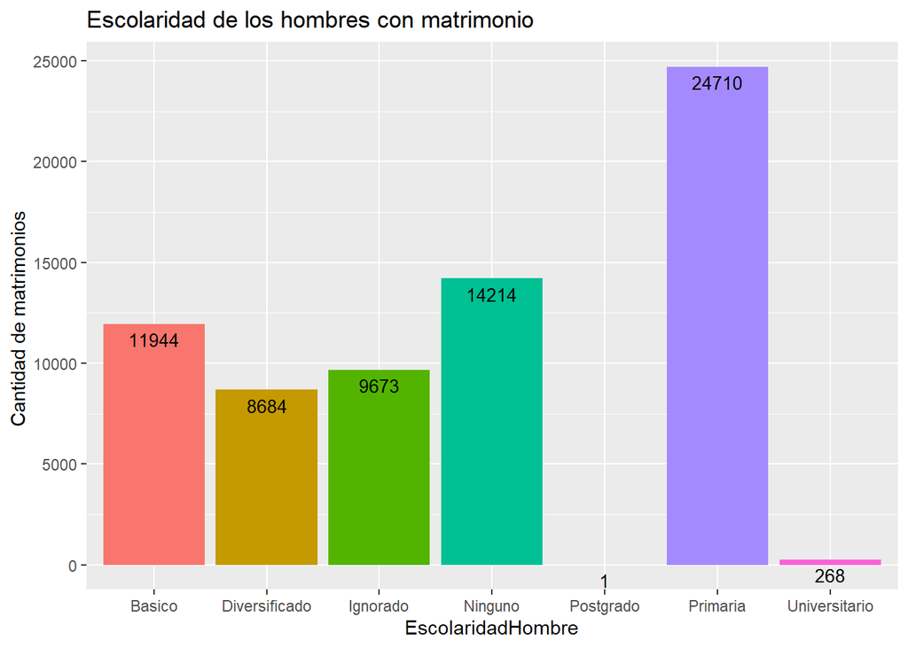

```r
PreguntaEscolaridad
```

Como se observa en la grafica se demuestra los hombres casados tienen el siguiente grado academico:

- **1 = No posee ninguna educacion con una cantidad de 14214**
- **2 = Educacion Primaria con una cantidad de 24710**
- **3 = Basico con una cantidad de 11944**
- **4 = Diversificado con una cantidad de 8684**
- **5 = Universitario con una cantidad de 268**
- **6 = Postgrado con una cantidad de 1**
- **9 = Ignorado con una cantidad de 9673**

Viendo en una grafica de pie

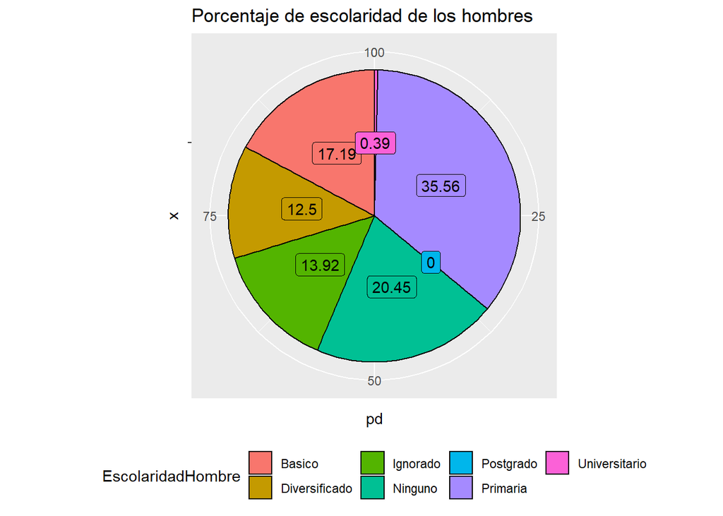

```r
pieEscH
```

Se observa que el grado con mayor porcentaje es primaria y siguiendole ninguno. Ahora enfocandonos en el sexo femenino se obtuvo lo siguiente

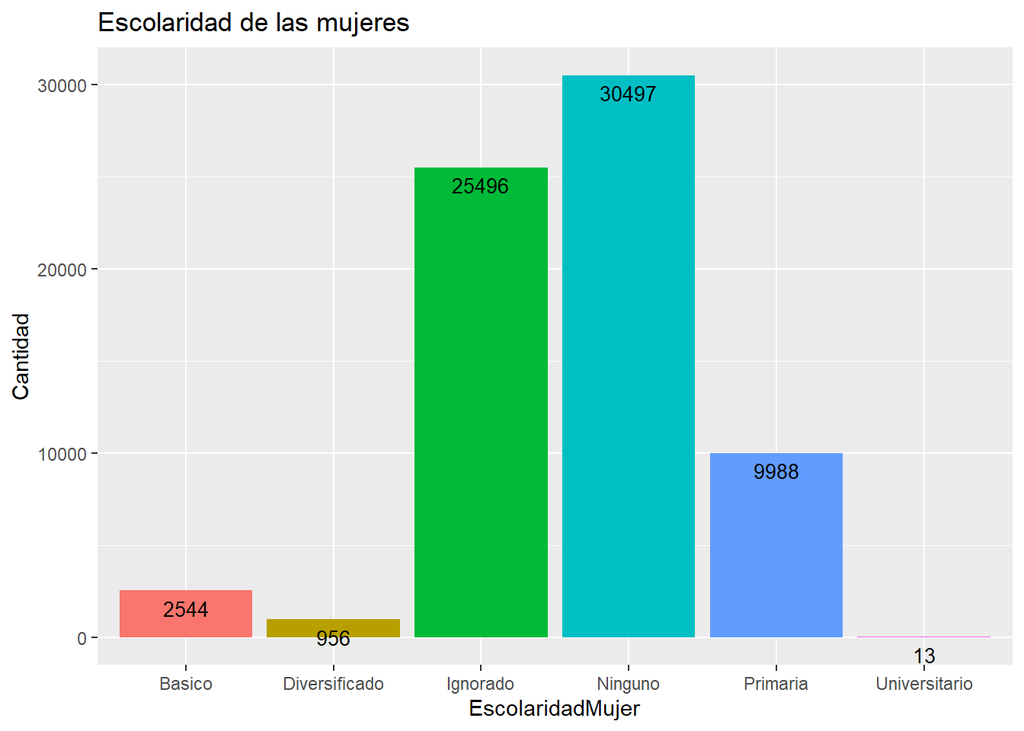

```r
PreguntaEscolaridadMujer
```

Como se observa en la grafica se demuestra los mujeres casados tienen el siguiente grado academico:  
* **1 = No posee ninguna educacion con una cantidad de 30497**  
* **2 = Educacion Primaria con una cantidad de 9988**  
* **3 = Basico con una cantidad de 2544**  
* **4 = Diversificado con una cantidad de 956**  
* **5 = Universitario con una cantidad de 13**  
* **6 = Postgrado con una cantidad de 0**  
* **9 = Ignorado con una cantidad de 25496**

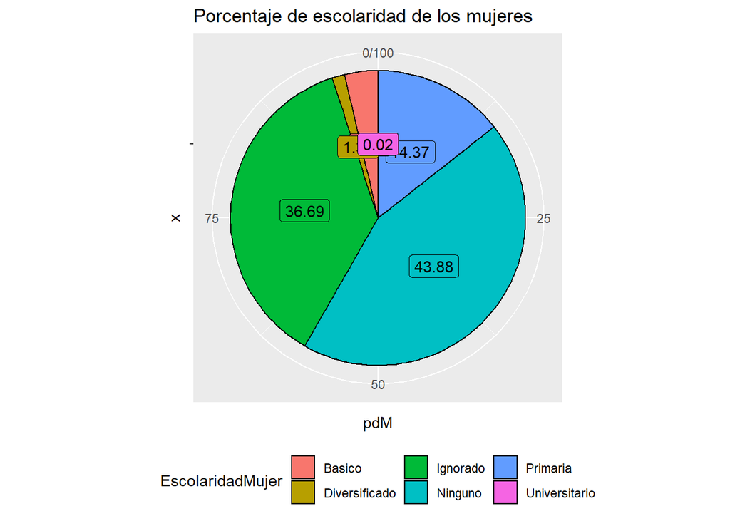

```r
pieEscM
```

### Analisis Exploratorio, sección de tendencias.

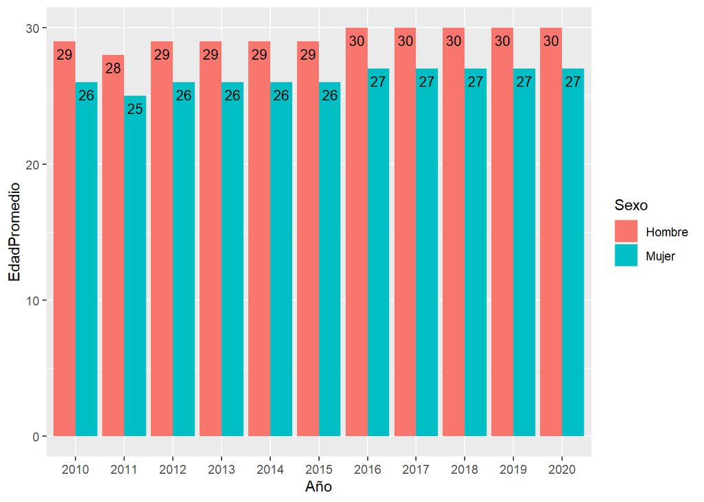

```r
pregunta1
```

Tal como se observa en la grafica anterior la edad promedio del hombre al contraer matrimonio es de **29**, mientras que la de la mujer es de **26**, cabe mencionar que en los ultimos años se demostro que las personas se estan casando a una edad mayor que antes, , tal como se observa en el año 2011, donde se ve que la edad de la mujer y del hombre es menor al resto de años. Esto puede ser debido al cambio de mentalidad de las personas, ya que la idea de contraer matrimonio a temprana edad va desapareciendo.

#### Moda de las edades de las parejas en los 10 años de registro

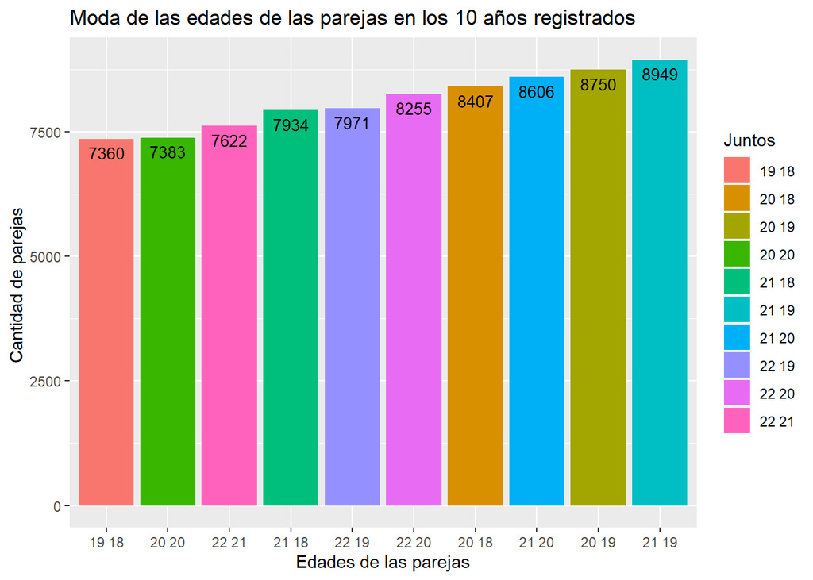

```r
pregunta2
```

La grafica anterior demuestra la moda de las edades de las parejas al contraer matrimonio, demostrando que la de edad de **21** años para hombre y **19** años para mujer es la mas habitual para unir lazos, se registro **8949** matrimonios cuando el hombre tiene **21** años y la mujer **19**, ademas que en segundo puesto se encuentra cuando el hombre tiene **20** y su pareja **19**.

### Cual es departamento con mas matrimonios?:

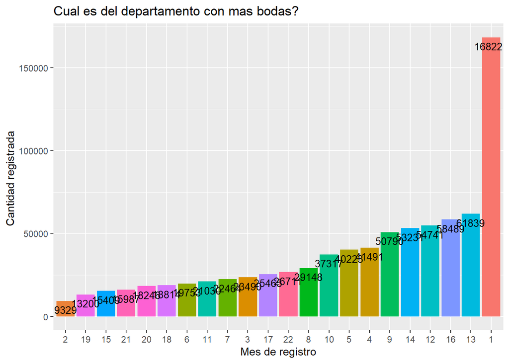

```r
pregunta1.2
```

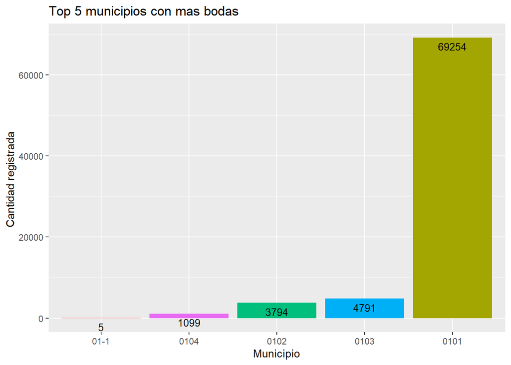

```r
pregunta1EH
```

En el gráfico podemos observar que el municipio donde se han realizado más bodas es en el municipio 0101 que corresponde al municipio de Guatemala del departamento de Guatemala, y le sigue San José Pinula, Guatemala; Santa Catarina Pinula, Guatemala; San José del Golfo; Guatemala y San Raymundo; Guatemala. Todos pertenecientes al departamento de Guatemala.

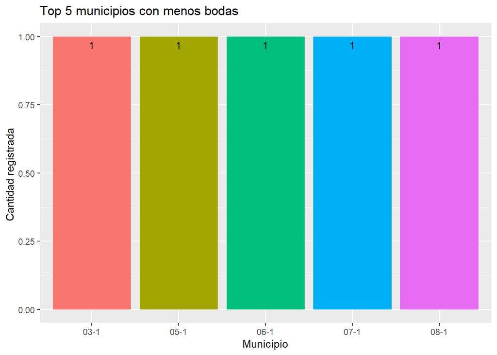

```r
pregunta2EH
```

### Maximo de bodas registradas en un dia

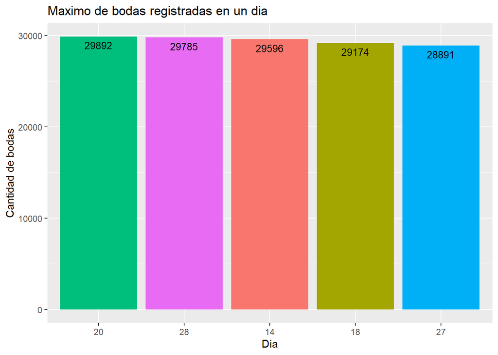

```r
pregunta2ED
```

En este gráfico podemos observar los 5 días donde se registraron mas matrimonios en el mismo día.

### Cual es el mes con mayor cantidad de matrimonios registrados?

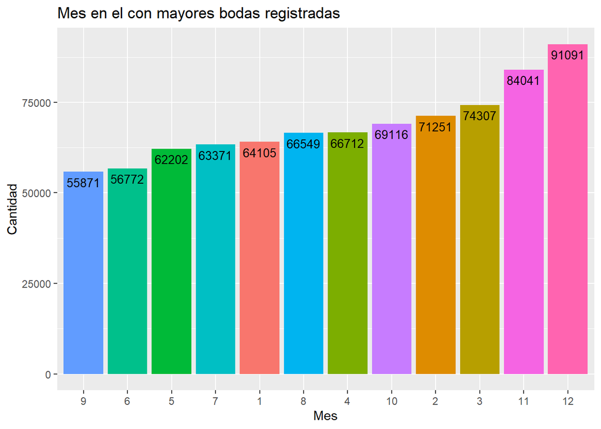

```r
pregunta2.2
```

El mes de diciembre es el mes en el que mas cantidad de matrimonios se han registrado a lo largo de los 10 años que analizamos, seguido del mes de noviembre, lo cual tiene mucha logica, ya que en estas fechas es cuando mas se suele celebrar o bien llevar a cabo los matrimonios, lo que es de cierta forma sorprendente, es que el mes de septiembre es el que contiene menor cantidad de bodas registradas.

### Porcentaje de Escolaridad tanto para hombres como mujeres por año:

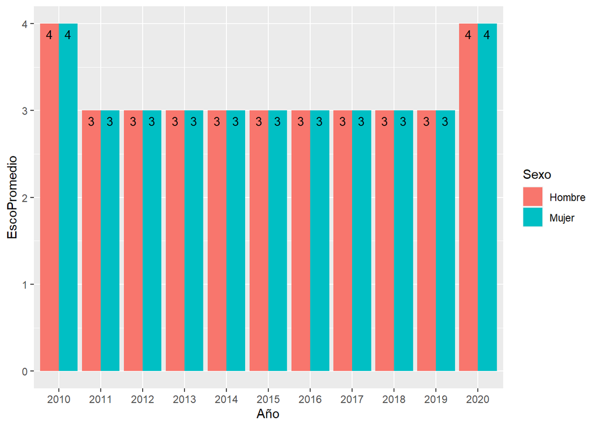

```r
pregunta4.2
```

### Cual es la clase de union mas utilizada en Guatemala?:

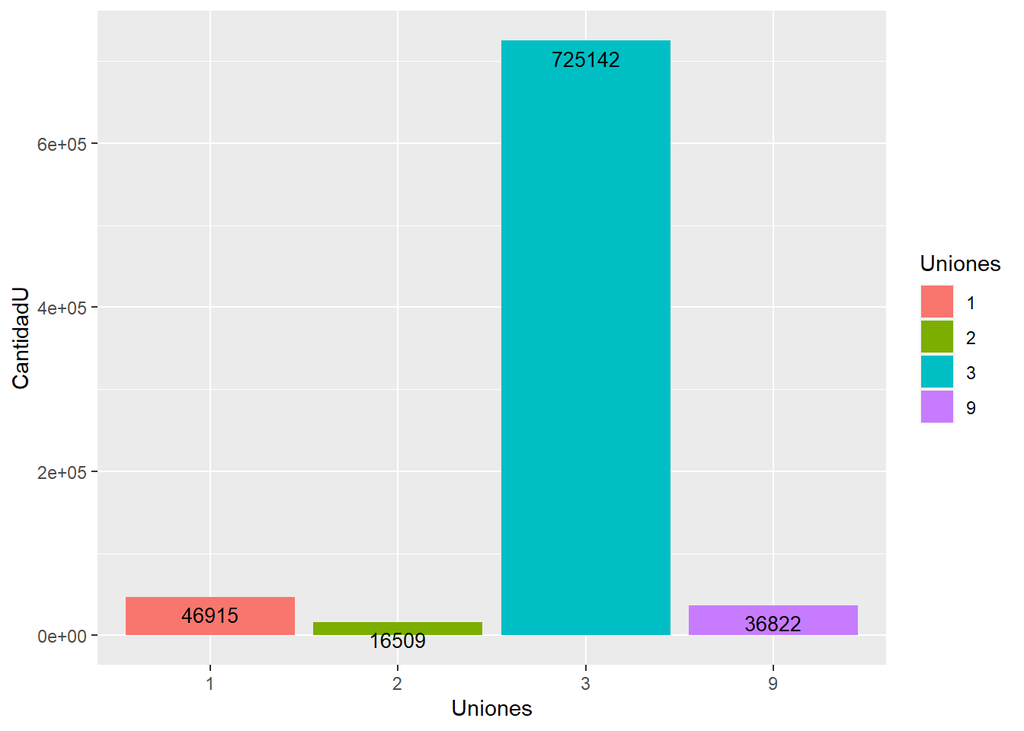

```r
pregunta5.2
```

El metodo de union mas comun de ver en los 10 años analizados, es el metodo numero 3 o la opcion 3, el cual hace referencia a COMUNIDAD DE GANANCIALES, esto quiere decir que durante su vigencia sólo uno de los cónyuges administra los bienes comunes, pero al término de la sociedad se dividen los gananciales por mitad a ambos., que como se explica anteriormente es la Comunidad de gananciales es la clara ganadora, por una cantidad abrumadora, seguido de la clase de union 1, que es la COMUNIDAD ABSOLUTA y la numero 9 que es NO ESPECIFICADO respectivamente.

### Cantidad de extranjeros registrados en Guatemala

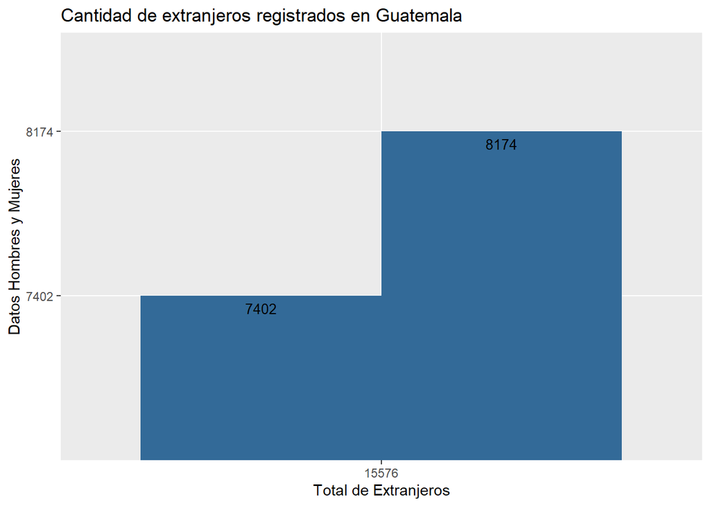

```r
pregunta1Ed
```

Como dato curioso investigamos la cantidad de extranjeros registrados en algun matrimonio en Guatemala y en la grafica podemos observar que existen 7402 hombres extranjeros y 8174 mujeres extranjeras siendo un total de 15576 personas extranjeras registradas en algun matrimonio en Guatemala

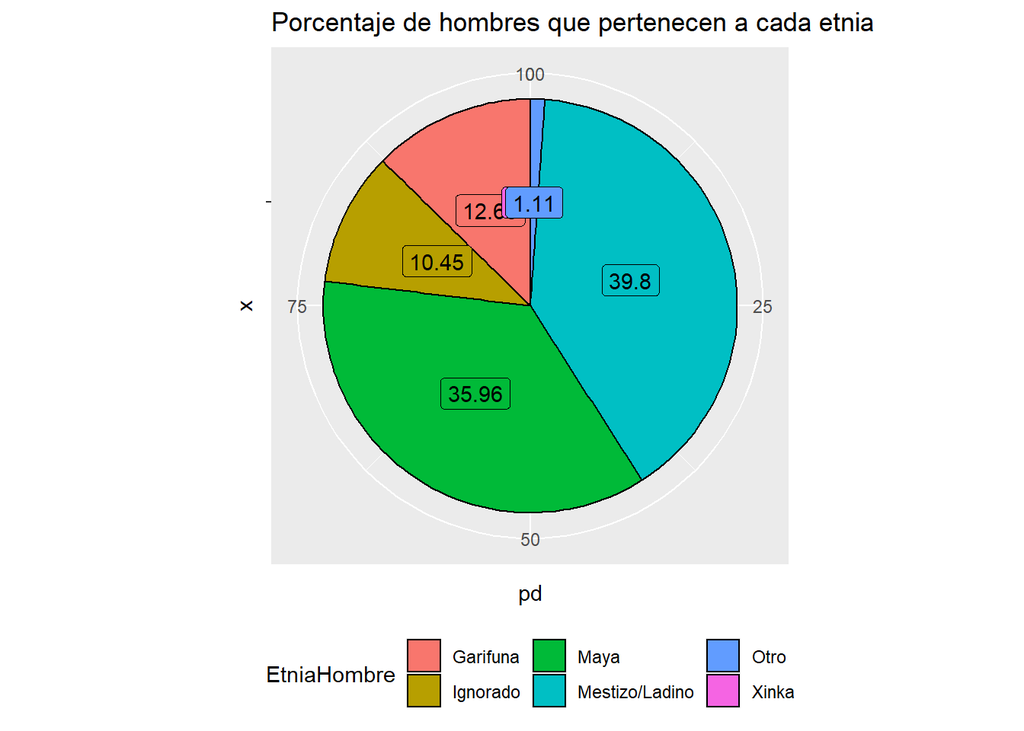

```r
pregunta3EH
```

Del gráfico anterior se observa que la mayoría, un 39.8%, de los hombres casados son mestizos o ladinos. 35.96% son mayas, 12.68% son garifunas, 1.11% son de otras etnias y el 10.45% son datos ignorados. Entonces podemos decir que la gran parte de los hombres son mestizos o ladinos y mayas.

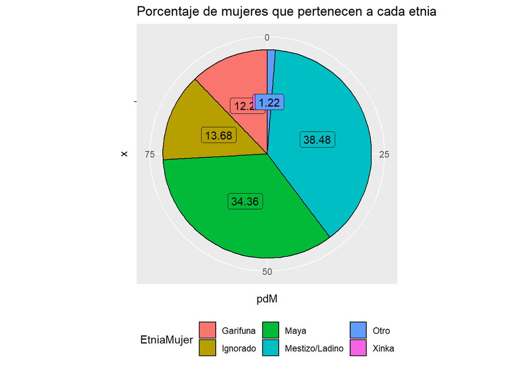

```r
pregunta4EH
```

En el caso de las mujeres, 38.48% son mestizas o ladinas, 34.36% son mayas, 12.26% son garifunas, 1.22% son de otras etnias y el 13.68% de los datos son ignorados. Muy similar al caso de los hombres, las mayoría de las mujeres son mestizas o ladinas y mayas.

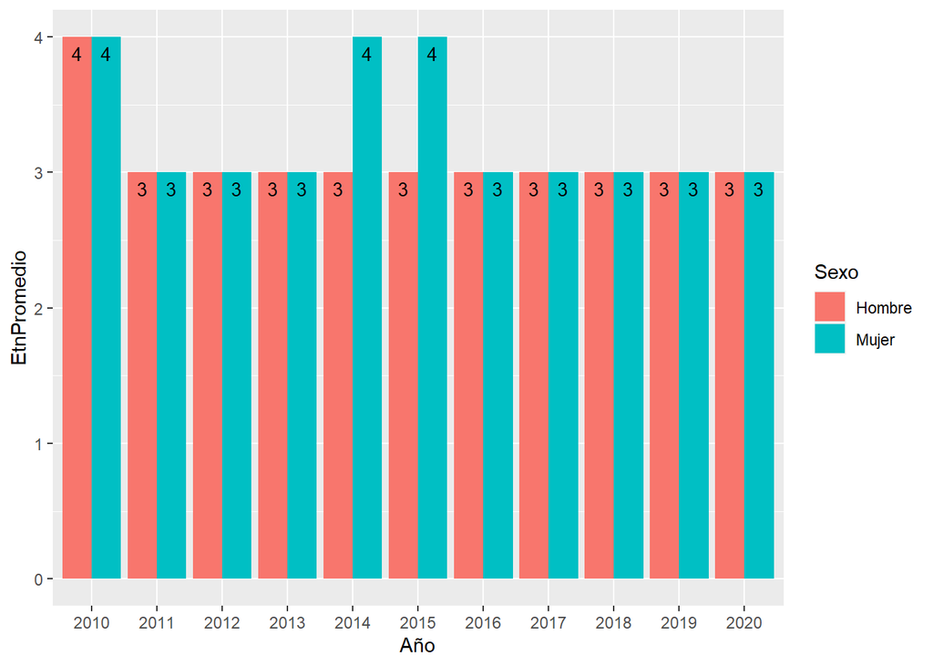

```r
pregunta5EH
```

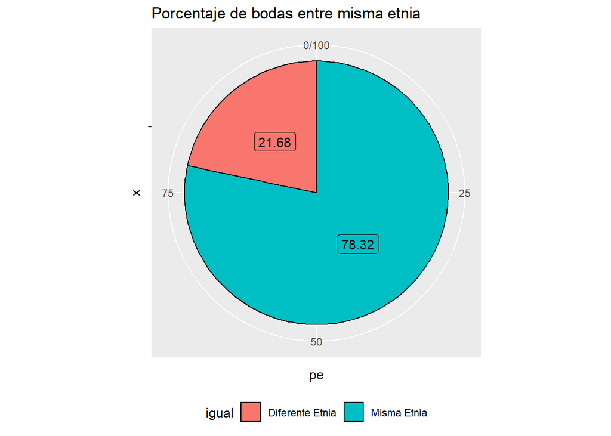

```r
pregunta6EH
```

De este gráfico se concluye que el 78.32% de las bodas, realizadas desde el 2010 hasta el 2020 y que fueron registradas, fueron entre personas de la misma etnia. Y el 21.68% fueron entre diferentes etnias.

### Clustering

Para el cluster se utilizo una muestra de 1000 registros, ya que al ser una gran base de datos y por cuestiones de optimizacion era lo mas recomendable. Para que el cluster funcione de manera correcta debemos de aplicarlo con las variables numericas. Las cuales son las edades.

```r
#Normalizado
datos[,6:7]<-scale(datos[,6:7])
#Experimento repetible
set.seed(123)
```

Tras normalizar los datos podemos observar si vale la pena o no hacer el agrupamiento de datos, esto lo decidimos mediante el estadistico de Hopkings.

```r
hopkins(datos[,6:7])
```

```
## [1] 0.9999951
```

El cual se observa que el valor esta alejado de 0.5 por lo que los datos no son aleatorios y existen altas posibilades de que sea factible el agrupamiento. Posteriormente para conocer cuantos grupos debemos de usar utilizamos varios metodos directos y metodo de prueba estadistica.

Primero pusimos a prueba el metodo de codo.

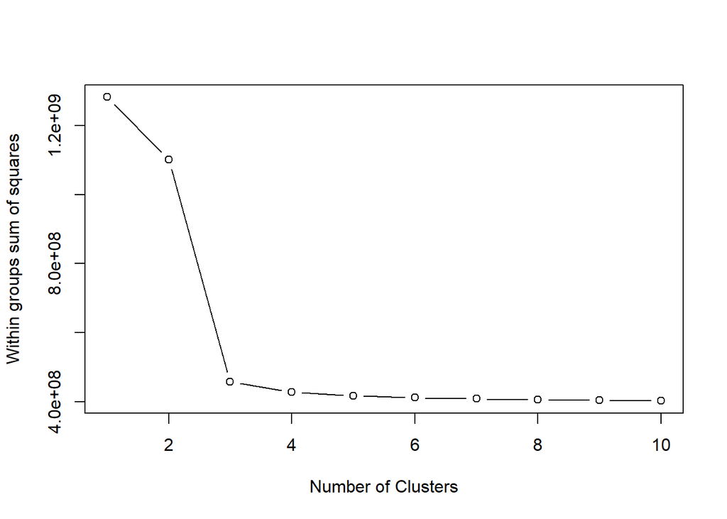

```r
#Metodo de codo


wss=0
for (i in 1:10)
  wss[i] <- sum(kmeans(db[,6:7], centers=i)$withinss)

plot(1:10, wss, type="b", xlab="Number of Clusters",  ylab="Within groups sum of squares")
```

Luego mediante el metodo de elbow, el cual nuevamente nos sugirio utilizar dos clusters.

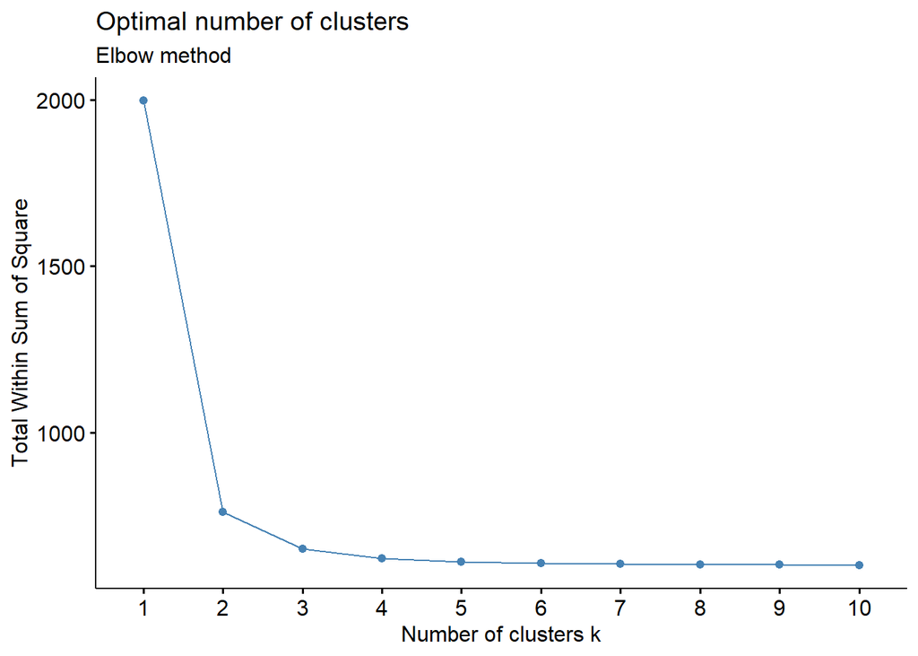

```r
#Elbow
fviz_nbclust(datos[,6:7], kmeans, method = "wss") +  labs(subtitle = "Elbow method")
```

El metodo de silueta tambien nos sugirio 2 clusters.

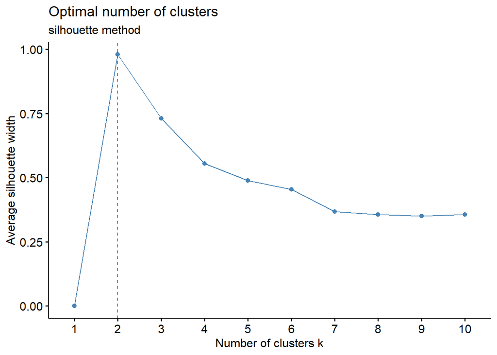

```r
#Silhoutte
fviz_nbclust(datos[,6:7], kmeans, method = "silhouette") +  labs(subtitle = "silhouette method")
```

```r
#Paquete NbClust
nb <- NbClust(datos[,6:7], distance = "euclidean", min.nc = 2,max.nc = 10, method = "complete", index ="all")
```

```
## [1] "Frey index : No clustering structure in this data set"
```

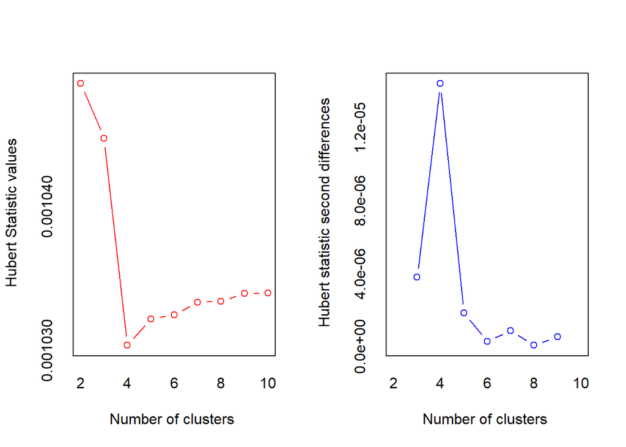